```python
%load_ext autoreload
%autoreload 2

# Reload dependencies
%reload_ext autoreload
```

# Introduction

This notebook is for analyzing the synthetically generated dataset.

```python
from utils_json import load_json_from_directory, load_json_file

structured_representations_json = load_json_from_directory(directory_path="./../dataset/truth/json/", as_dict=True)

ocr_results_markdown = load_json_from_directory(directory_path="./../dataset/ocr/markdown/", as_dict=True)
ocr_results_text = load_json_from_directory(directory_path="./../dataset/ocr/text/", as_dict=True)

from utils_text_files import load_text_files_from_directory

inputs_markdown = load_text_files_from_directory(directory_path="./../dataset/input/cleaned_markdown/", as_dict=True)
inputs_text = load_text_files_from_directory(directory_path="./../dataset/input/cleaned_text/", as_dict=True)

train_examples_ids = load_json_file("./split/training_example_ids.json")
test_examples_ids = load_json_file("./split/test_example_ids.json")
print(f"Loaded {len(train_examples_ids)} training examples ids")
print(f"Loaded {len(test_examples_ids)} test examples ids")
```

```
Loaded 320 training examples ids
Loaded 80 test examples ids
```

```python
def summarize_selection_mark_states(structured_representation):
    """
    Aggregates the 'state' values from a structured JSON template, typically used in questionnaires
    or forms where each question can have multiple choices with states indicating selection status.

    Parameters:
        json_template (dict): A dictionary representing structured data with questions and choices.
                              Each choice in the question list has a 'state' that indicates whether it
                              is selected or not.

    Returns:
        list: A list of all 'state' values across all choices in all questions within the json_template.
              This can include states like 'selected', 'unselected', etc.
    """
    states = []
    for question in structured_representation["questions"]:
        for choice in question["choices"]:
            states += [choice["state"]]

    return states

def count_expected_selection_marks(structured_representation):
    """
    Counts the number of 'selected' and 'unselected' states in a structured data format,
    typically used in questionnaires or forms where choices are marked by users.

    Parameters:
        structured_representation (dict): A dictionary representing the structured data,
                                          typically containing a list of questions,
                                          each with a list of choice options and their states.

    Returns:
        tuple: A tuple (num_selected, num_unselected) representing the count of
               'selected' and 'unselected' choice states across all questions.
    """
    num_selected, num_unselected = 0, 0

    for question in structured_representation["questions"]:
        for choice in question["choices"]:
            if choice["state"] == "selected":
                num_selected += 1
            elif choice["state"] == "unselected":
                num_unselected += 1

    return num_selected, num_unselected

def count_detected_selection_marks(input):
    """
    Counts occurrences of ':selected:' and ':unselected:' in a string input.
    This function is useful for parsing raw text data where selections are
    explicitly marked within the text.

    Parameters:
        input (str): The string input containing the selection marks.

    Returns:
        tuple: A tuple (num_selected, num_unselected) representing the count of
               ':selected:' and ':unselected:' substrings in the input.
    """

    return str(input).count(":selected:"), str(input).count(":unselected:")

def process_selection_marks(selections_marks):
    """
    Categorizes selection marks into selected and unselected,
    and calculates the centroids of the polygons for each category.

    Parameters:
        selections_marks (list of dict): A list of dictionaries where each dictionary
                                         represents a selection mark containing a state,
                                         a polygon (list of coordinates), and other properties.

    Returns:
        tuple: A tuple containing two lists of centroids:
               1. Centroids of selected polygons.
               2. Centroids of unselected polygons.

    Raises:
        ValueError: If the state of any selection mark is not 'selected' or 'unselected'.
    """
    selected_centroids = []
    unselected_centroids = []

    # Iterate over each selection mark
    for selection_mark in selections_marks:
        # Check the state is valid
        state = selection_mark['state']
        if state not in ['selected', 'unselected']:
            raise ValueError(f"Invalid state '{state}'. State must be either 'selected' or 'unselected'.")

        # Extract the polygon and calculate its centroid
        polygon = selection_mark['polygon']
        # Assuming the polygon is a flat list of coordinates [x1, y1, x2, y2, ..., xn, yn]
        n = len(polygon) // 2  # Number of vertices
        x_centroid = sum(polygon[i] for i in range(0, len(polygon), 2)) / n
        y_centroid = sum(polygon[i] for i in range(1, len(polygon), 2)) / n
        centroid = (x_centroid, y_centroid)

        # Categorize based on state
        if state == 'selected':
            selected_centroids.append(centroid)
        elif state == 'unselected':
            unselected_centroids.append(centroid)

    # Return the tuple of centroids lists
    return (selected_centroids, unselected_centroids)
```

```python
import pandas as pd

# Start of your existing code
# Initialize the list that will hold all the data rows
data_rows = []

# Loop over each key in structured_representations_json
for key in structured_representations_json:
    gt_json = structured_representations_json[key]

    markdown_selection_marks = ocr_results_markdown[key]["pages"][0]["selectionMarks"]
    markdown_input = inputs_markdown[key]

    text_selection_marks = ocr_results_text[key]["pages"][0]["selectionMarks"]
    text_input = inputs_text[key]

    # Use ground truth to determine expected number of selected / unselected checkboxes
    num_selected, num_unselected = count_expected_selection_marks(gt_json)

    # Number of detected :selected: and :unselected: tokens in markdown / text inputs
    count_selected_markdown, count_unselected_markdown  = count_detected_selection_marks(markdown_input)
    count_selected_text, count_unselected_text  = count_detected_selection_marks(text_input)

    # Categorize polygons / centroids
    centroids_selected_markdown, centroids_unselected_markdown = process_selection_marks(markdown_selection_marks)
    centroids_selected_text, centroids_unselected_text = process_selection_marks(text_selection_marks)

    # Prepare a dictionary representing the row to add to the DataFrame
    row = {
        "example_id": key,
        "language": str(key).split("_")[0],
        "split": "train" if key in train_examples_ids else "test",
        "gt_states": summarize_selection_mark_states(gt_json),
        "gt_num_selected": num_selected,
        "gt_num_unselected": num_unselected,
        "count_selected_markdown": count_selected_markdown,
        "count_unselected_markdown": count_unselected_markdown,
        "selected_centroids_markdown": centroids_selected_markdown,
        "unselected_centroids_markdown": centroids_unselected_markdown,
        "selected_centroids_text": centroids_selected_text,
        "unselected_centroids_text": centroids_unselected_text,
        "count_selected_text": count_selected_text,
        "count_unselected_text": count_unselected_text
    }

    # Append the row dictionary to the list
    data_rows.append(row)

# Convert the list of dictionaries into a DataFrame
df_dataset_attributes = pd.DataFrame(data_rows)

# Calculate the differences between GT and detected counts for both markdown and text
df_dataset_attributes['diff_gt_selected_markdown'] = df_dataset_attributes['gt_num_selected'] - df_dataset_attributes['count_selected_markdown']
df_dataset_attributes['diff_gt_unselected_markdown'] = df_dataset_attributes['gt_num_unselected'] - df_dataset_attributes['count_unselected_markdown']

df_dataset_attributes['diff_gt_selected_text'] = df_dataset_attributes['gt_num_selected'] - df_dataset_attributes['count_selected_text']
df_dataset_attributes['diff_gt_unselected_text'] = df_dataset_attributes['gt_num_unselected'] - df_dataset_attributes['count_unselected_text']

print(df_dataset_attributes)
```

```
      example_id language  split  \
0     arabic_001   arabic  train
1     arabic_002   arabic  train
2     arabic_003   arabic  train
3     arabic_004   arabic  train
4     arabic_005   arabic  train
..           ...      ...    ...
395  spanish_046  spanish  train
396  spanish_047  spanish  train
397  spanish_048  spanish  train
398  spanish_049  spanish   test
399  spanish_050  spanish  train

                                             gt_states  gt_num_selected  \
0    [selected, unselected, unselected, unselected,...               12
```

[output cut: 116 more lines]

# Data Analysis

### Probability a given answer choice is selected or unselected in the examples...

#### Overall the probability is ~50%

```python
# Extracting the answer choices from 'gt_states'
choice_counts = {i: {'selected': 0, 'unselected': 0} for i in range(1, 27)}  # Dictionary to store counts

for index, row in df_dataset_attributes.iterrows():
    states = row['gt_states']
    for i, state in enumerate(states, start=1):
        if state == 'selected':
            choice_counts[i]['selected'] += 1
        elif state == 'unselected':
            choice_counts[i]['unselected'] += 1

# Transforming the dictionary into a DataFrame for easier plotting
df_choices = pd.DataFrame.from_dict(choice_counts, orient='index')

df_choices['total'] = df_choices['selected'] + df_choices['unselected']
df_choices['prop_selected'] = df_choices['selected'] / df_choices['total']
df_choices['prop_unselected'] = df_choices['unselected'] / df_choices['total']
```

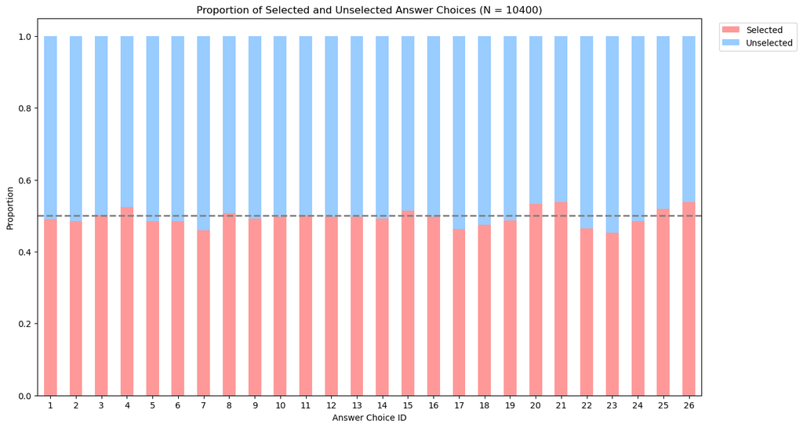

```python
import matplotlib.pyplot as plt

# Plotting the data with a reference line and pastel colors
fig, ax = plt.subplots(figsize=(14, 8))
df_choices[['prop_selected', 'prop_unselected']].plot(kind='bar', stacked=True, color=['#ff9999', '#99ccff'], ax=ax)

ax.set_title(f'Proportion of Selected and Unselected Answer Choices (N = {len(choice_counts) * len(df_dataset_attributes)})') # 26 answer choices * N = 400 examples
ax.set_xlabel('Answer Choice ID')
ax.set_ylabel('Proportion')
ax.set_xticks(range(26))  # Set x-ticks to be every answer choice ID
ax.set_xticklabels(range(1, 27), rotation=0)  # Label x-ticks with answer choice IDs
plt.legend(['Selected', 'Unselected'], loc='upper right', bbox_to_anchor=(1.15, 1))

# Adding a horizontal line at y=0.5 to represent random selection threshold
ax.axhline(0.5, color='gray', linewidth=2, linestyle='--')

plt.show()
```

#### By Language (still reasonably balanced i.e., probability remains ~50%)

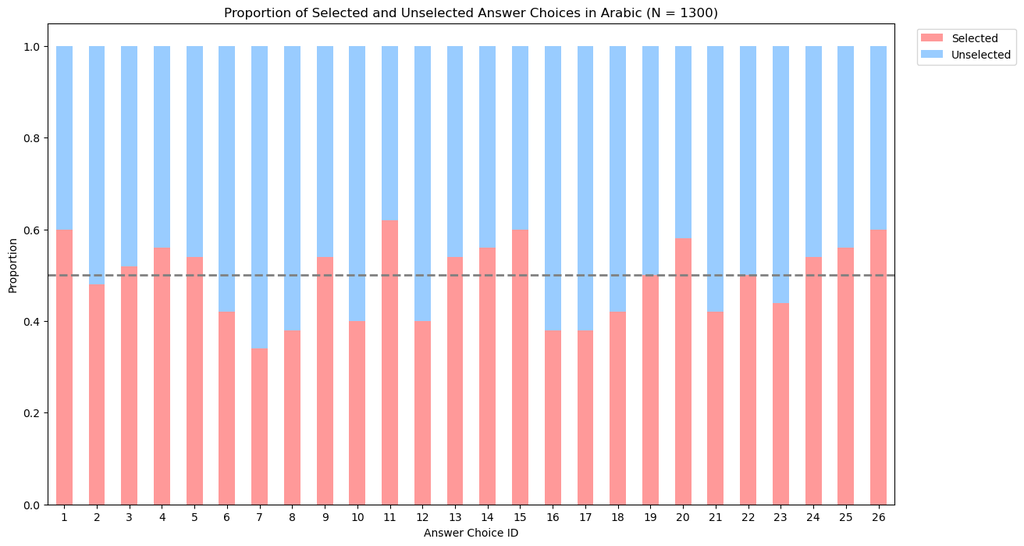

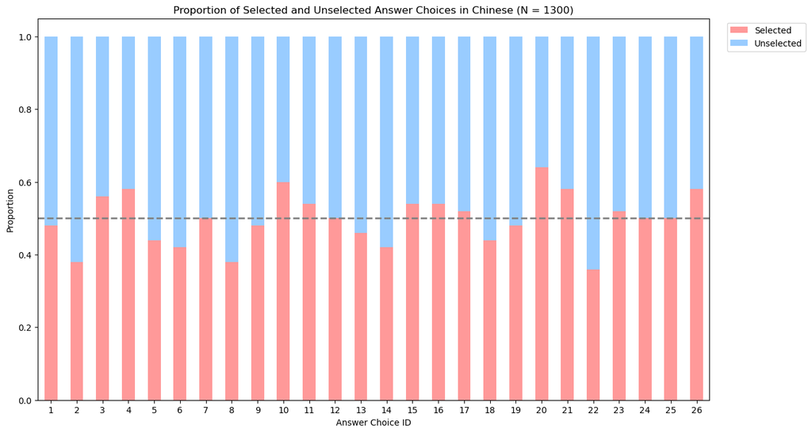

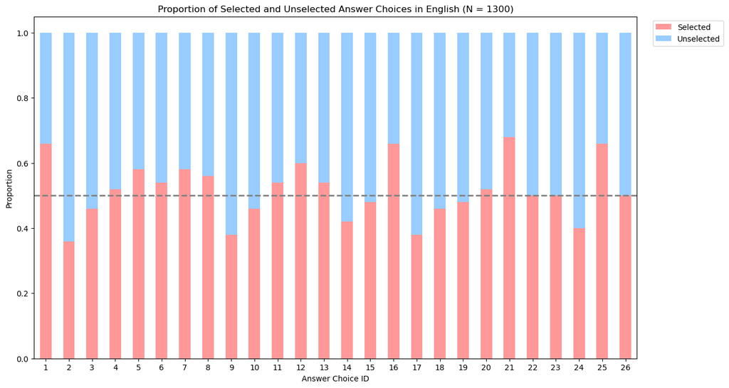

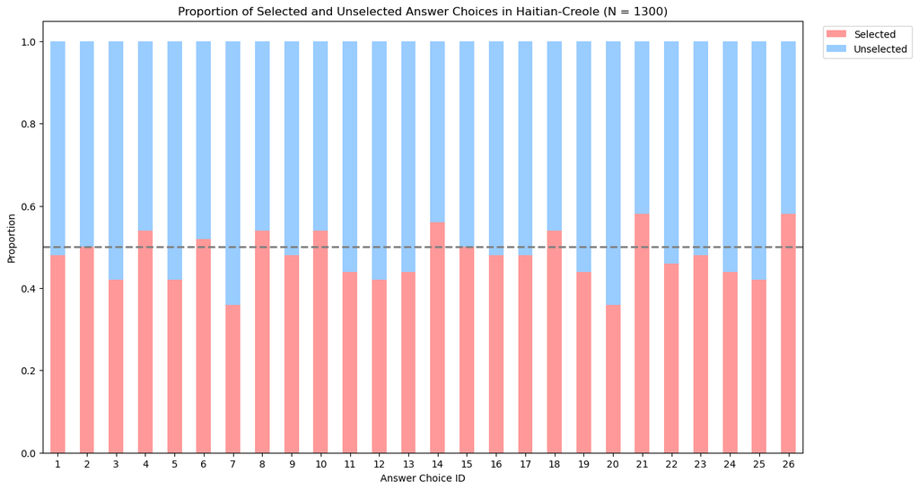

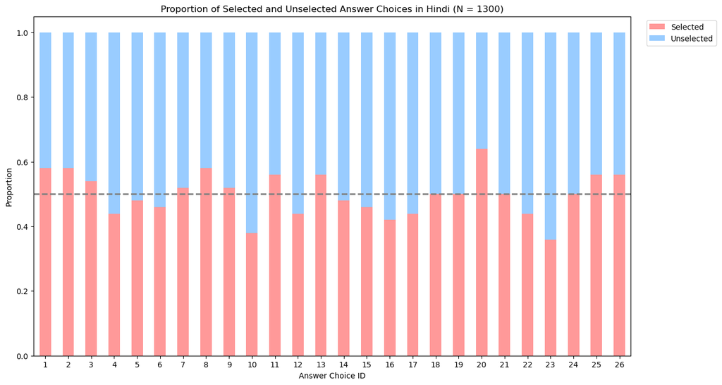

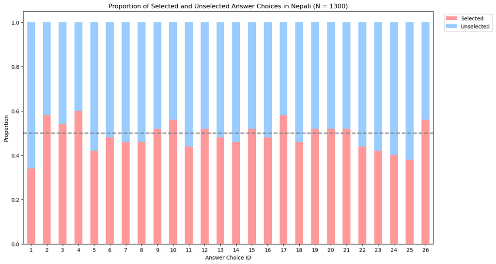

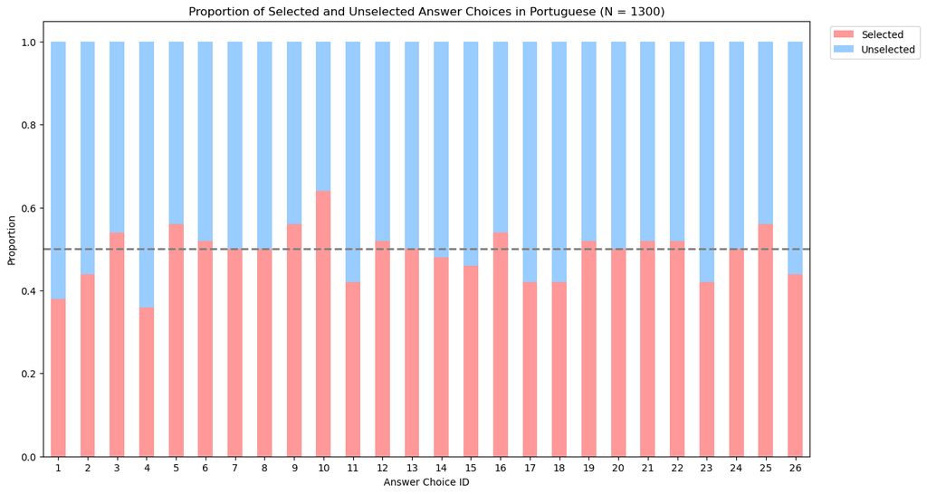

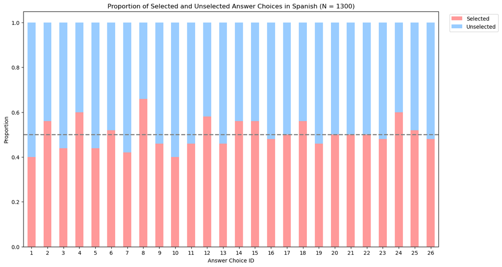

```python
# Define a function to calculate and plot the data for each language
def plot_language_data(df, language):
    # Initialize dictionary for choice counts
    choice_counts = {i: {'selected': 0, 'unselected': 0} for i in range(1, 27)}

    # Filter data for the current language
    lang_df = df[df['language'] == language]

    # Count selected and unselected for each choice
    for index, row in lang_df.iterrows():
        states = row['gt_states']
        for i, state in enumerate(states, start=1):
            if state == 'selected':
                choice_counts[i]['selected'] += 1
            elif state == 'unselected':
                choice_counts[i]['unselected'] += 1

    # Transform the dictionary into a DataFrame
    df_choices = pd.DataFrame.from_dict(choice_counts, orient='index')
    df_choices['total'] = df_choices['selected'] + df_choices['unselected']
    df_choices['prop_selected'] = df_choices['selected'] / df_choices['total']
    df_choices['prop_unselected'] = df_choices['unselected'] / df_choices['total']

    # Plotting the data
    fig, ax = plt.subplots(figsize=(14, 8))
    df_choices[['prop_selected', 'prop_unselected']].plot(kind='bar', stacked=True, color=['#ff9999', '#99ccff'], ax=ax)
    ax.set_title(f'Proportion of Selected and Unselected Answer Choices in {language.title()} (N = {len(choice_counts) * len(lang_df)})')
    ax.set_xlabel('Answer Choice ID')
    ax.set_ylabel('Proportion')
    ax.set_xticks(range(26))
    ax.set_xticklabels(range(1, 27), rotation=0)
    plt.legend(['Selected', 'Unselected'], loc='upper right', bbox_to_anchor=(1.15, 1))
    ax.axhline(0.5, color='gray', linewidth=2, linestyle='--')
    plt.show()

# Get a list of unique languages
languages = df_dataset_attributes['language'].unique()

# Generate a plot for each language
for language in languages:
    plot_language_data(df_dataset_attributes, language)
```

### Consistency in number of detected selected / unselected answer choices suggests LLM will have sufficient information for the task; however, extra selected answer choices could be distracting

```python
summary_stats = df_dataset_attributes[['diff_gt_selected_markdown', 'diff_gt_unselected_markdown',
                                      'diff_gt_selected_text', 'diff_gt_unselected_text']].describe()
print(summary_stats)
```

```
       diff_gt_selected_markdown  diff_gt_unselected_markdown  \
count                 400.000000                        400.0
mean                   -0.875000                          0.0
std                     0.331133                          0.0
min                    -1.000000                          0.0
25%                    -1.000000                          0.0
50%                    -1.000000                          0.0
75%                    -1.000000                          0.0
max                     0.000000                          0.0

       diff_gt_selected_text  diff_gt_unselected_text
count             400.000000                    400.0
mean               -0.875000                      0.0
std                 0.331133                      0.0
min                -1.000000                      0.0
25%                -1.000000                      0.0
50%                -1.000000                      0.0
75%                -1.000000                      0.0
max                 0.000000                      0.0
```

- For selected checkboxes, there is an over-detection issue, where the OCR/OMR systems detect more selected checkboxes than are actually present in the ground truth.
- For unselected checkboxes, the detection is perfectly aligned with the ground truth, indicating that the systems are highly reliable in not falsely detecting unselected checkboxes as selected.

**The extra checkboxes detected are likely because the questionnaires' instructions include a checkmark.**

```python
from utils_analyze_dataset import identify_problematic_examples

identify_problematic_examples(df_dataset_attributes)
```

```
Example ID: chinese_001
GT Selected: 11, GT Unselected: 15 (Total: 26)
Count Selected Markdown: 12, Count Unselected Markdown: 15 (Total: 27)
Count Selected Text: 12, Count Unselected Text: 15 (Total: 27)
Problems identified:
 - Mismatch in 'selected' markdown (excess) - GT: 11, Detected: 12, Diff: -1
----------------------------------------
Example ID: chinese_002
GT Selected: 10, GT Unselected: 16 (Total: 26)
Count Selected Markdown: 11, Count Unselected Markdown: 16 (Total: 27)
Count Selected Text: 11, Count Unselected Text: 16 (Total: 27)
Problems identified:
 - Mismatch in 'selected' markdown (excess) - GT: 10, Detected: 11, Diff: -1
----------------------------------------
Example ID: chinese_003
GT Selected: 12, GT Unselected: 14 (Total: 26)
Count Selected Markdown: 13, Count Unselected Markdown: 14 (Total: 27)
Count Selected Text: 13, Count Unselected Text: 14 (Total: 27)
Problems identified:
 - Mismatch in 'selected' markdown (excess) - GT: 12, Detected: 13, Diff: -1
----------------------------------------
Example ID: chinese_004
GT Selected: 9, GT Unselected: 17 (Total: 26)
Count Selected Markdown: 10, Count Unselected Markdown: 17 (Total: 27)
Count Selected Text: 10, Count Unselected Text: 17 (Total: 27)
Problems identified:
 - Mismatch in 'selected' markdown (excess) - GT: 9, Detected: 10, Diff: -1
----------------------------------------
Example ID: chinese_005
GT Selected: 13, GT Unselected: 13 (Total: 26)
Count Selected Markdown: 14, Count Unselected Markdown: 13 (Total: 27)
Count Selected Text: 14, Count Unselected Text: 13 (Total: 27)
Problems identified:
 - Mismatch in 'selected' markdown (excess) - GT: 13, Detected: 14, Diff: -1
----------------------------------------
Example ID: chinese_006
GT Selected: 16, GT Unselected: 10 (Total: 26)
Count Selected Markdown: 17, Count Unselected Markdown: 10 (Total: 27)
Count Selected Text: 17, Count Unselected Text: 10 (Total: 27)
Problems identified:
```

[output cut: 2420 more lines]

```
Language: haitian-creole
  selected markdown (excess): 50 issues
----------------------------------------
Language: hindi
  selected markdown (excess): 50 issues
----------------------------------------
Language: nepali
  selected markdown (excess): 50 issues
----------------------------------------
Language: portuguese
  selected markdown (excess): 50 issues
----------------------------------------
Language: spanish
  selected markdown (excess): 50 issues
----------------------------------------
```

# Assessing Training vs. Test Split

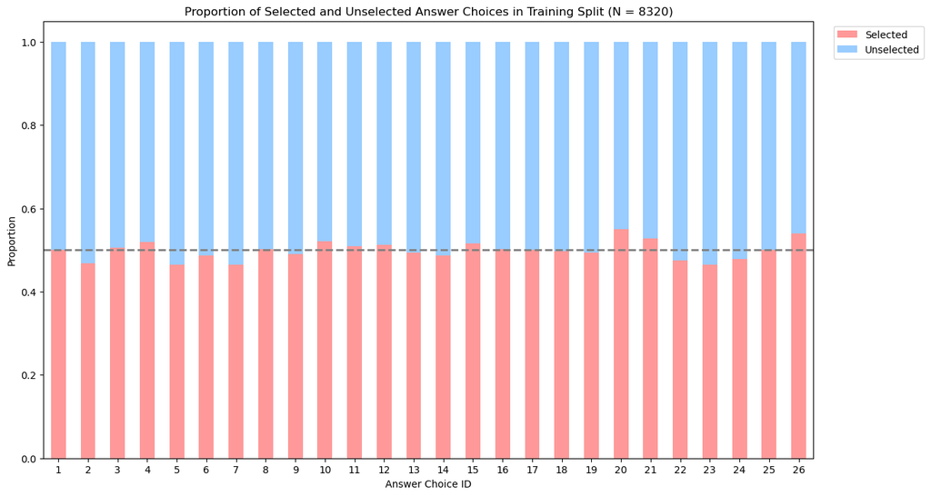

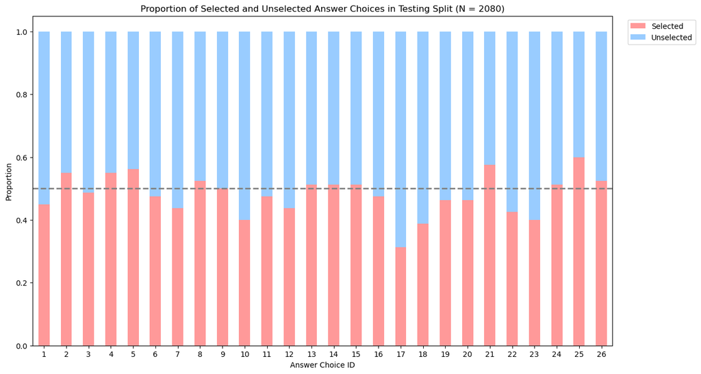

```python
# Define a function to calculate and plot the data for each split
def plot_split_data(df, split):
    # Initialize dictionary for choice counts
    choice_counts = {i: {'selected': 0, 'unselected': 0} for i in range(1, 27)}

    # Filter data for the current split
    split_df = df[df['split'] == split]

    # Count selected and unselected for each choice
    for index, row in split_df.iterrows():
        states = row['gt_states']
        for i, state in enumerate(states, start=1):
            if state == 'selected':
                choice_counts[i]['selected'] += 1
            elif state == 'unselected':
                choice_counts[i]['unselected'] += 1

    # Transform the dictionary into a DataFrame
    df_choices = pd.DataFrame.from_dict(choice_counts, orient='index')
    df_choices['total'] = df_choices['selected'] + df_choices['unselected']
    df_choices['prop_selected'] = df_choices['selected'] / df_choices['total']
    df_choices['prop_unselected'] = df_choices['unselected'] / df_choices['total']

    # Plotting the data
    fig, ax = plt.subplots(figsize=(14, 8))
    df_choices[['prop_selected', 'prop_unselected']].plot(kind='bar', stacked=True, color=['#ff9999', '#99ccff'], ax=ax)
    ax.set_title(f'Proportion of Selected and Unselected Answer Choices in {split.title()}ing Split (N = {len(choice_counts) * len(split_df)})')
    ax.set_xlabel('Answer Choice ID')
    ax.set_ylabel('Proportion')
    ax.set_xticks(range(26))
    ax.set_xticklabels(range(1, 27), rotation=0)
    plt.legend(['Selected', 'Unselected'], loc='upper right', bbox_to_anchor=(1.15, 1))
    ax.axhline(0.5, color='gray', linewidth=2, linestyle='--')
    plt.show()

# Set list of splits
splits = ["train", "test"]

# Generate a plot for each language
for split in splits:
    plot_split_data(df_dataset_attributes, split)
```